# Coding task 21.01.2021: Comapring distributions

# 1 Example data & libraries

```r
# install.packages("rattle.data")
# install.packages("ggridges")
library(rattle.data)
library(ggplot2)
library(ggpubr)

wine = wine
```

# 2 Different ways to visualise distributions

## 2.1 Plot the distribution of the wine color for the three different wine types

- Try to come up with different way to plot this
- Which is you favorite and why?

## 2.2 Here are some more, try them out

### 2.2.1 geom_density(), ggridges::geom_density_ridges(), geom_histogram()

- Try out different bins for the histogram
- What is the difference of a histogram to a density plot?

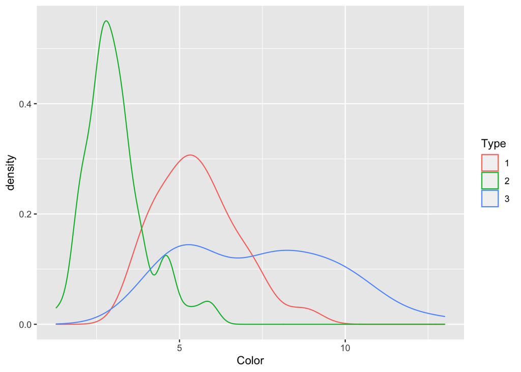

```r
ggplot(wine, aes(x =Color, color = Type))+
  geom_density()
```

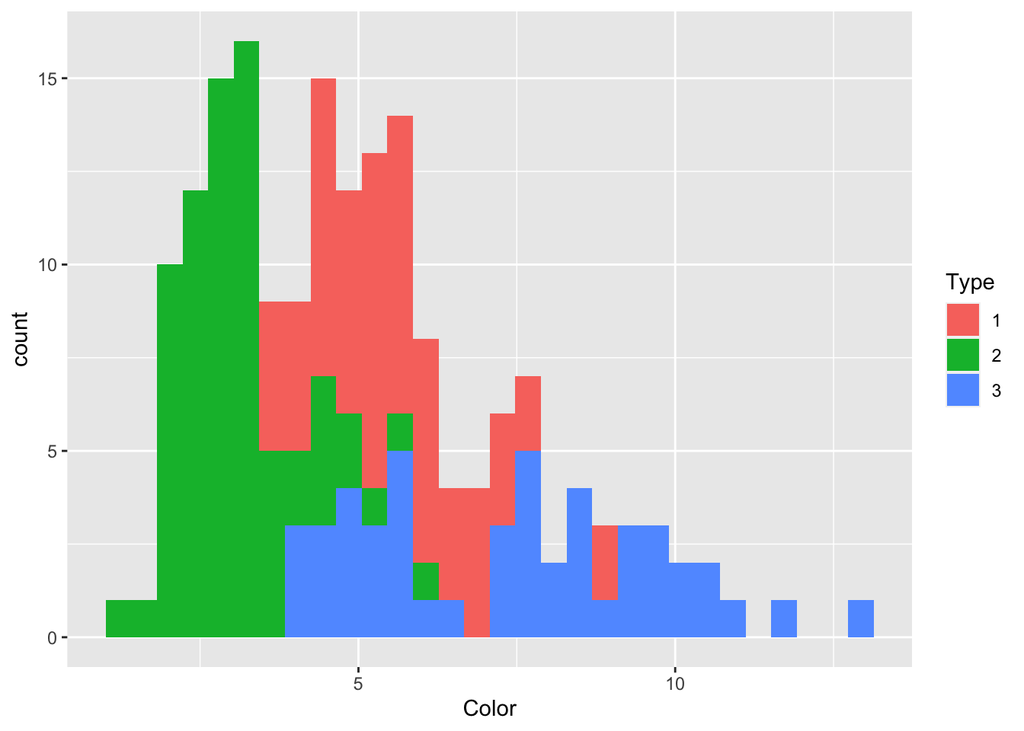

```r
ggplot(wine, aes(x =Color))+
  geom_histogram(aes( fill = Type))
```

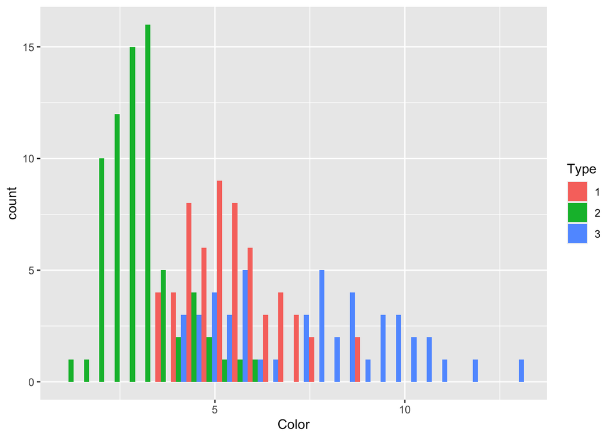

```r
ggplot(wine, aes(x =Color))+
  geom_histogram(aes( fill = Type), position = "dodge")
```

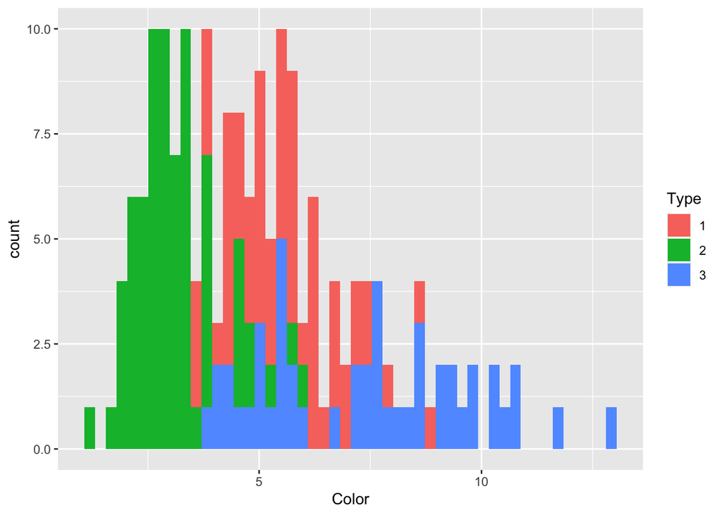

```r
ggplot(wine, aes(x =Color))+
  geom_histogram(aes(fill = Type), bins = 50)
```

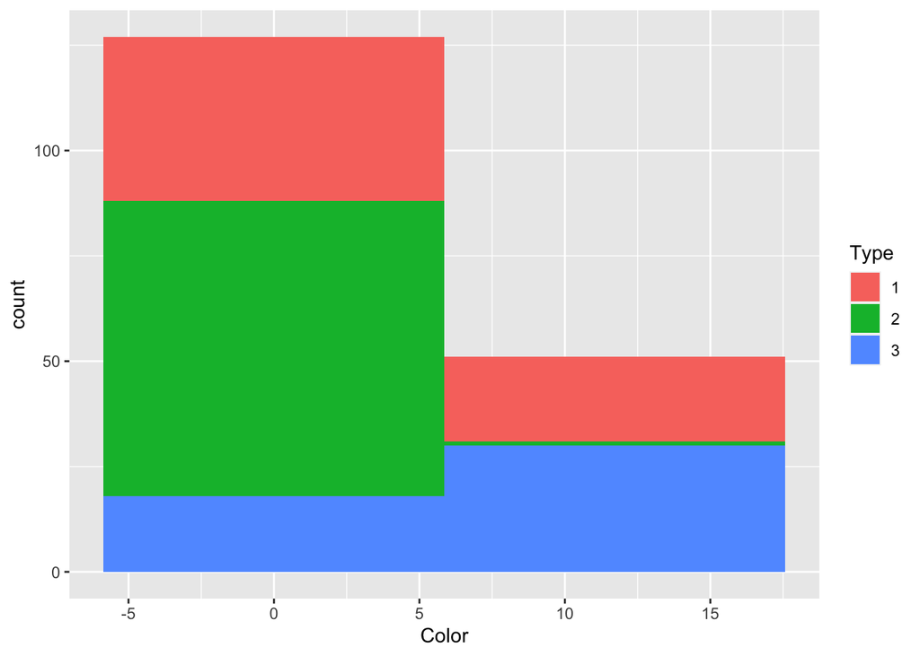

```r
ggplot(wine, aes(x =Color))+
  geom_histogram(aes(fill = Type), bins = 2)
```

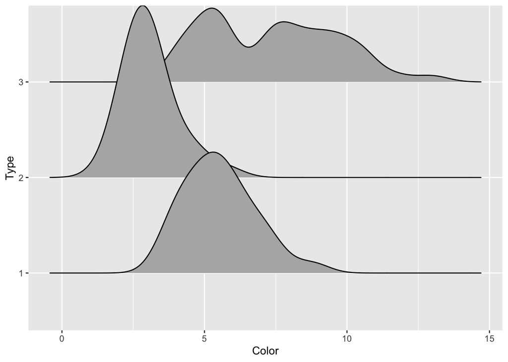

```r
ggplot(wine, aes(x =Color, y = Type))+
  ggridges::geom_density_ridges()
```

### 2.2.2 geom_boxplot(), geom_jitter(), geom_violin()

- How do these plots relate to a classical density plot?
- What information do you lose in which plot?
- You can also combine these three or two of them

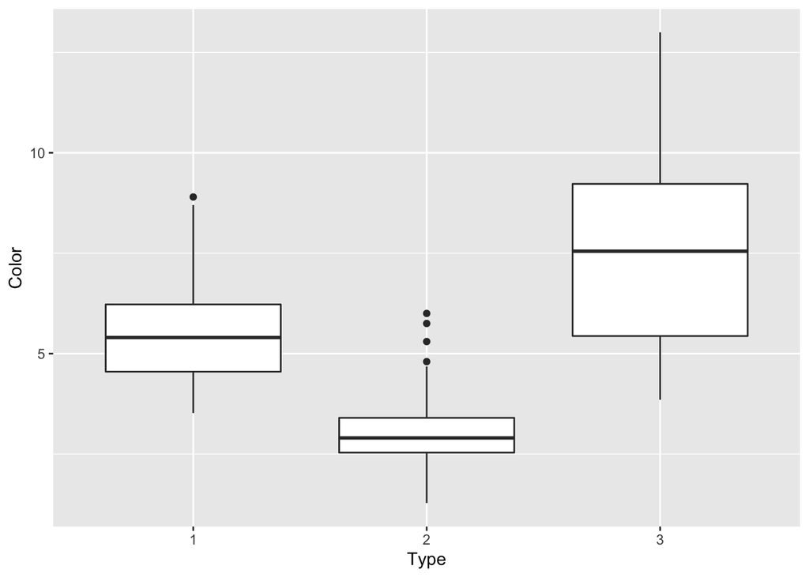

```r
ggplot(wine, aes(x =Type, y = Color))+
  geom_boxplot()
```

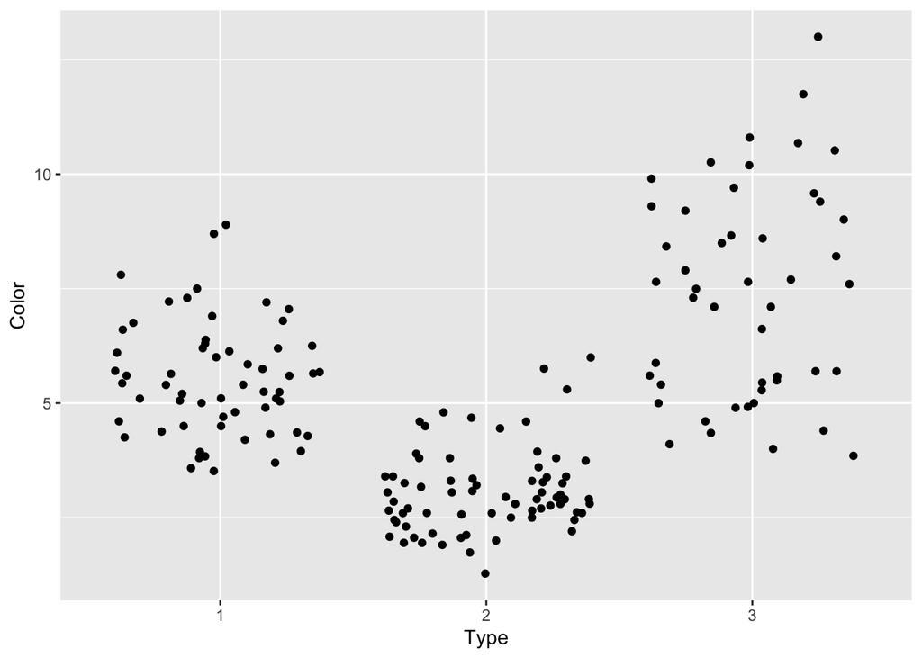

```r
ggplot(wine, aes(x =Type, y = Color))+
  geom_jitter()
```

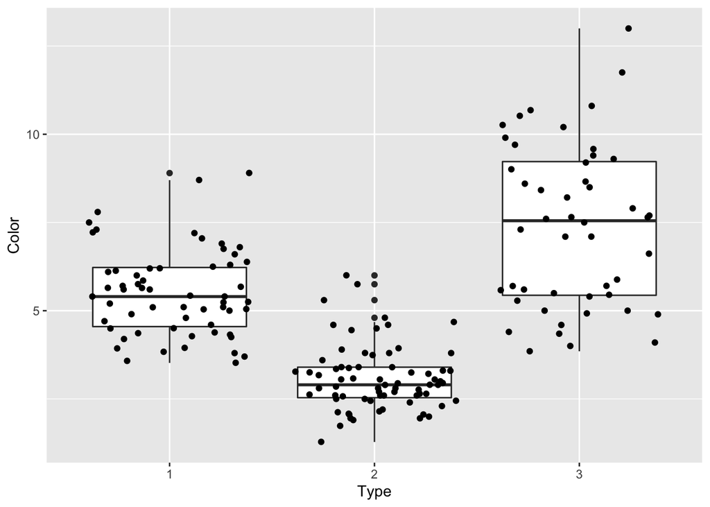

```r
ggplot(wine, aes(x =Type, y = Color))+
  geom_boxplot()+
  geom_jitter()
```

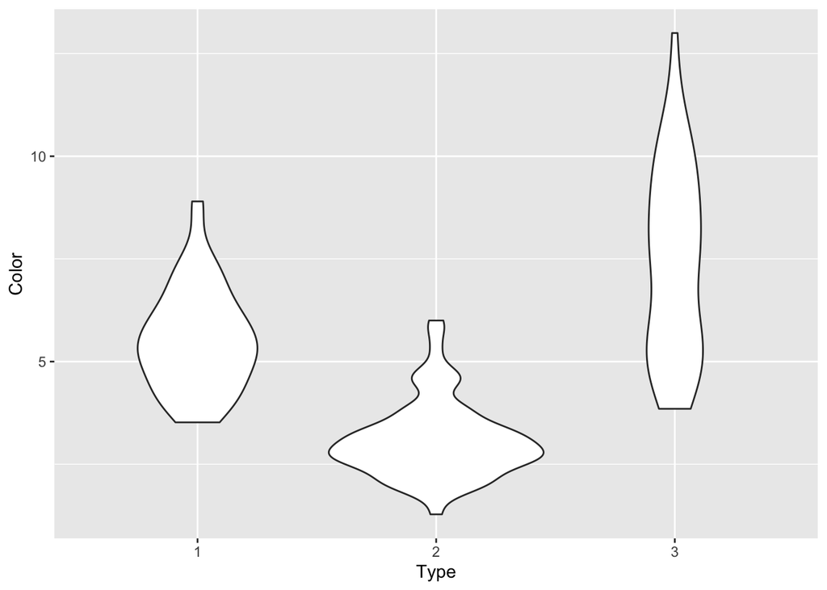

```r
ggplot(wine, aes(x =Type, y = Color))+
  geom_violin()
```

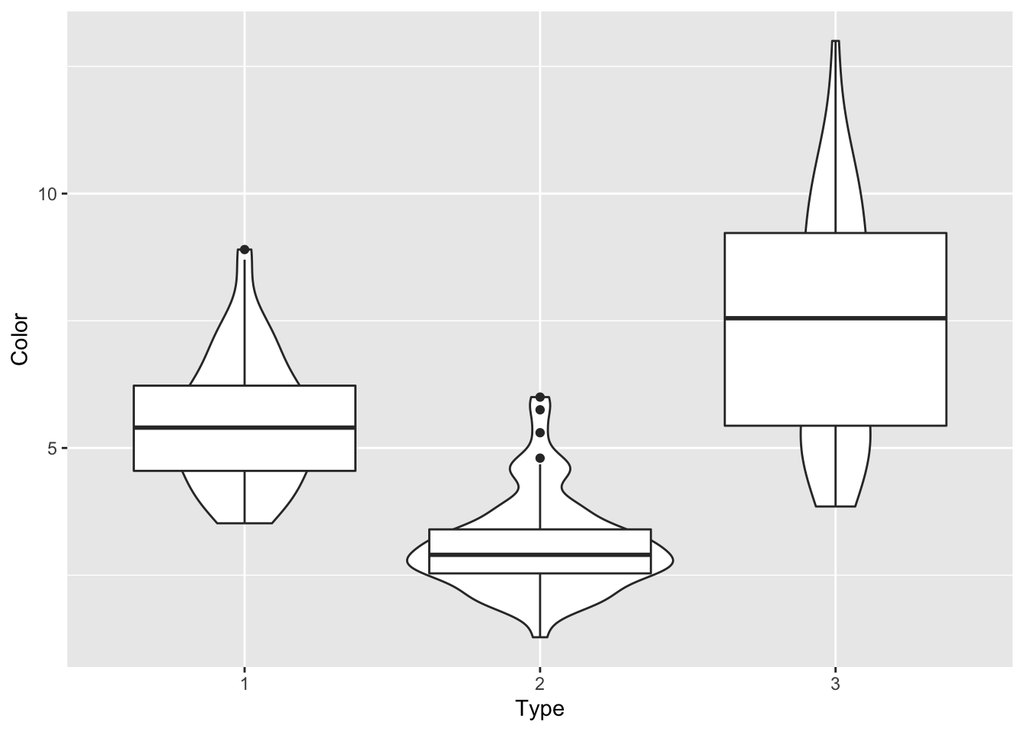

```r
ggplot(wine, aes(x =Type, y = Color))+
  geom_violin()+
  geom_boxplot()
```

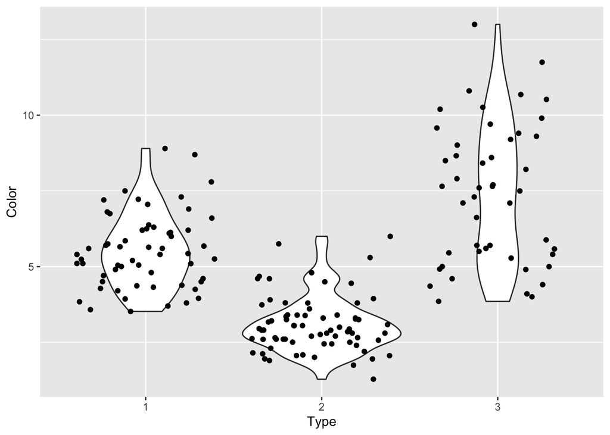

```r
ggplot(wine, aes(x =Type, y = Color))+
  geom_violin()+
  geom_jitter()
```

### 2.2.3 stat_ecdf()

- What does this plot show you?

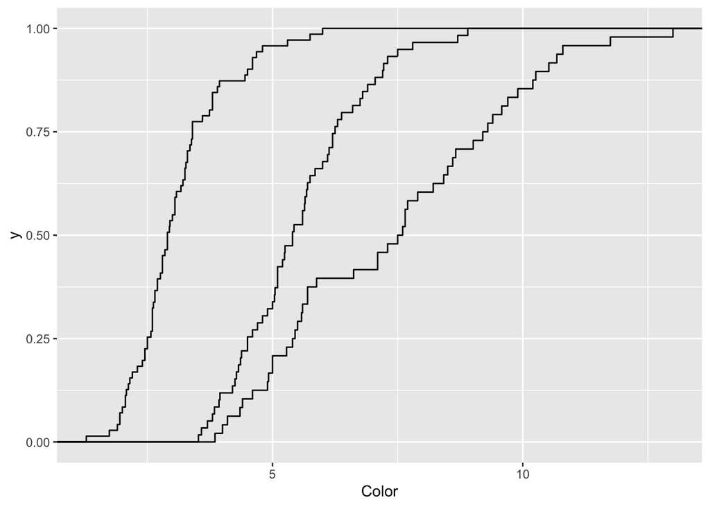

```r
ggplot(wine, aes(x =Color, fill = Type))+
  stat_ecdf()
```

# 3 Statistical tests to compare distributions (of continous values)

## 3.1 What is a p-value? How would you explain it?

## 3.2 compare_means(), stat_compare_means()

- Compare_means() statisticaly compares two values
- stat_compare_means() can be added directly to a ggplot with plot + stat_compare_means() and adds the p-values to the plot

- Which statistical test is used by default?
- How do the p-values change, if you use method = “t-test”
- When would you use “t-test” as method instead?
- Use ggqqplot() and the shapiro.test() to decide if you could use a t-test here

```r
compare_means(Color ~ Type, data=wine[wine$Type !=3,] )
```

[output not shown]

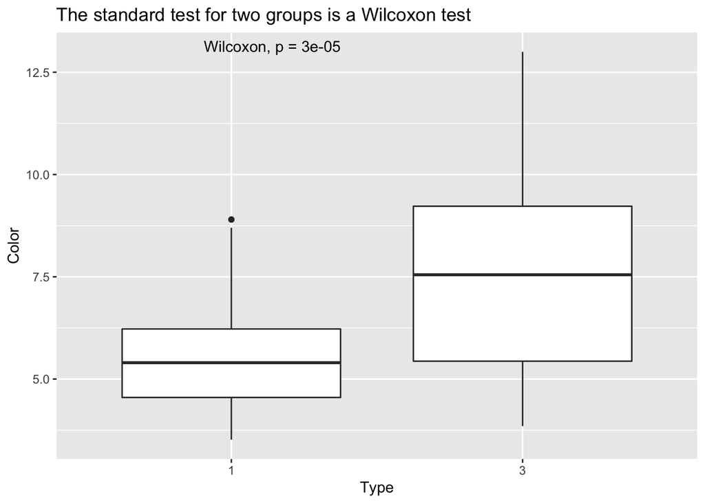

```r
# ! attention
# compare_means(Type ~ Color, data=wine[wine$Type !=3,] ) does not work x~y, x must be numeric y is the grouping

ggplot(wine[wine$Type !=2,], aes(x =Type, y = Color))+
  geom_boxplot()+
  stat_compare_means()+
  ggtitle( "The standard test for two groups is a Wilcoxon test")
```

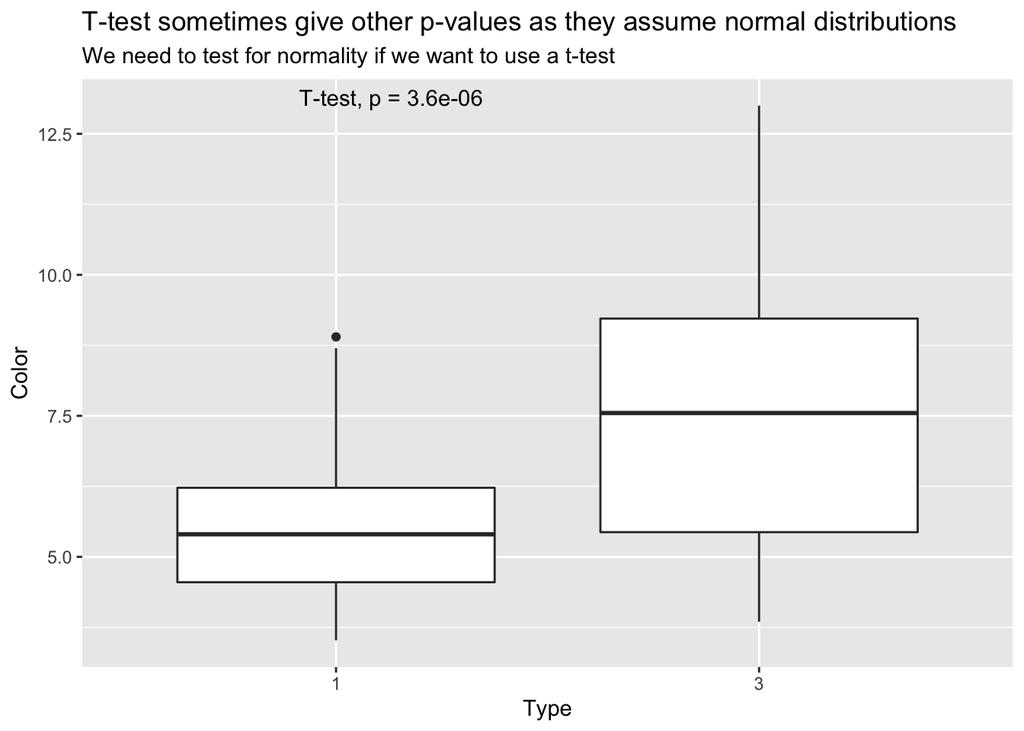

```r
ggplot(wine[wine$Type !=2,], aes(x =Type, y = Color))+
  geom_boxplot()+
  stat_compare_means(method = "t.test")+
  ggtitle("T-test sometimes give other p-values as they assume normal distributions", subtitle = "We need to test for normality if we want to use a t-test")
```

```r
##########
# test for normality
#########
shapiro.test(wine[wine$Type==1,]$Color)
```

```
##
##  Shapiro-Wilk normality test
##
## data:  wine[wine$Type == 1, ]$Color
## W = 0.96819, p-value = 0.1251
```

```r
shapiro.test(wine[wine$Type==2,]$Color)
```

```
##
##  Shapiro-Wilk normality test
##
## data:  wine[wine$Type == 2, ]$Color
## W = 0.93175, p-value = 0.0008195
```

```r
shapiro.test(wine[wine$Type==3,]$Color)
```

```
##
##  Shapiro-Wilk normality test
##
## data:  wine[wine$Type == 3, ]$Color
## W = 0.95849, p-value = 0.08775
```

```r
shapiro.test(wine$Color)
```

```
##
##  Shapiro-Wilk normality test
##
## data:  wine$Color
## W = 0.94032, p-value = 9.229e-07
```